# CMSC320_Final_Project

### **Global Air Quality Trends and Health Implications**

### **Spring 2024 Data Science Project**

#### **By Wenzhuo Niu, Shaoyu Yan**

Member 1: Wenzhuo Niu, Contribution: 100%.

Member 2: Shaoyu Yan, Contribution: 100%.

We, all team members, agree together that the above information is true, and we are confident about our contributions to this submitted project/final tutorial.

Wenzhuo Niu 5/6/2024

Shaoyu Yan 5/6/2024

## Detailed Contribution Summary

**Group Member Contributions**

### Wenzhuo Niu:

- **Project Idea (5%):** Initiated and defined the project scope and objectives, ensuring alignment with academic and industry standards.
- **Dataset Curation and Preprocessing (10%):** Led the efforts in identifying, curating, and preprocessing the data to ensure quality and relevance for the analysis.
- **Data Exploration and Summary Statistics (10%):** Conducted thorough data exploration, providing detailed summary statistics that set the foundation for further analysis.
- **ML Algorithm Design/Development (25%):** Designed and developed the machine learning algorithms, focusing on model architecture and integration with data processing pipelines.
- **ML Algorithm Training and Test Data Analysis (20%):** Managed the training processes, evaluated model performance using test datasets, and fine-tuned parameters to optimize outcomes.
- **Visualization, Result Analysis, Conclusion (15%):** Created insightful visualizations to depict findings and drafted the analysis and conclusions based on the results obtained.
- **Final Tutorial Report Creation (10%):** Compiled and refined the final tutorial report, ensuring it met all criteria for submission and dissemination.
- **Additional Contributions (5%):** Engaged in additional tasks such as literature review and contextual research to enhance the project's depth and relevance.

### Shaoyu Yan:

- **Project Idea (5%):** Co-developed the initial project idea, contributing innovative approaches to the project's aim and execution.
- **Dataset Curation and Preprocessing (10%):** Assisted in data collection and preprocessing, ensuring data integrity and usability.
- **Data Exploration and Summary Statistics (10%):** Analyzed the data to extract meaningful patterns and trends, supporting the project's analytical framework.
- **ML Algorithm Design/Development (25%):** Collaborated in the coding and refinement of machine learning algorithms, ensuring they were robust and scalable.
- **ML Algorithm Training and Test Data Analysis (20%):** Participated in model training sessions, analyzed performance metrics, and suggested improvements.
- **Visualization, Result Analysis, Conclusion (15%):** Took the lead on developing dynamic visualizations that clearly communicated the project findings to a diverse audience.
- **Final Tutorial Report Creation (10%):** Played a key role in writing and editing the final report, focusing on clarity, accuracy, and alignment with project goals.
- **Additional Contributions (5%):** Provided support in administrative tasks and documentation, enhancing project coordination and execution.

## **Introduction**

Air quality significantly affects public health, ecosystem health, and global climate. As industrial activities increase and urban areas develop, it becomes increasingly important to monitor and understand the dynamics of air quality for effective policy-making, public health planning, and environmental protection. This data science project uses a global air pollution dataset to examine air quality trends across different regions and their effects on health and the environment.

The main goal of this analysis is to identify patterns and trends in air quality indices (AQIs) from cities worldwide, with a focus on major pollutants like carbon monoxide (CO), nitrogen dioxide (NO2), ozone (O3), and particulate matter (PM2.5). These pollutants have well-documented negative impacts on health and are regulated globally. This project will analyze how AQI varies with geographical and temporal factors and how these variations affect public health:

1. What are the regional variations in air quality, and what are the contributing factors?
2. How does air quality affect public health in terms of pollution-related diseases, and how can data-driven insights help mitigate these impacts?

These questions are critical to answer for several reasons. Understanding regional air quality variations helps identify areas with severe pollution, requiring targeted actions. Moreover, correlating air quality data with health outcomes enables a clearer quantification of the health burdens from air pollution, which can guide healthcare priorities and interventions.

This analysis is vital beyond academic purposes. With ongoing challenges like urbanization and climate change, the insights from data-driven analyses are crucial. They inform policymakers, shape public health responses, and guide conservation efforts. Moreover, understanding air quality trends enables communities to advocate for healthier environments, influencing both local and global sustainability efforts.

This project seeks to unravel the complexities of air pollution and contribute to a broader understanding of environmental data science. By using advanced statistical and machine learning techniques, it models the complex interactions between air pollutants and their impacts, providing a versatile analytical framework for future environmental health studies.

In conclusion, exploring global air quality data is essential for public health, policymaking, and environmental management. This project aims to offer a comprehensive analysis that enhances understanding of air quality trends and motivates further research and actions for a healthier, more sustainable future.

```python
# Import necessary libraries
import pandas as pd
import numpy as np
from scipy import stats
import seaborn as sns
import matplotlib.pyplot as plt
import numpy as np
import pandas as pd
import seaborn as sns
from sklearn.model_selection import train_test_split
from sklearn.linear_model import LinearRegression
from sklearn.metrics import mean_squared_error, r2_score
```

## **2. Data Curation**

#### **Data Source**

Global Air Pollution Dataset from Kaggle: https://www.kaggle.com/datasets/hasibalmuzdadid/global-air-pollution-dataset/data

#### **1. Loading Data**

```python
# Load the dataset
file_path = 'global air pollution dataset.csv'
air_pollution_data = pd.read_csv(file_path)

# Display the first few rows of the dataframe
air_pollution_data.head()
```

|  | Country | City | AQI Value | AQI Category | CO AQI Value | CO AQI Category | Ozone AQI Value | Ozone AQI Category | NO2 AQI Value | NO2 AQI Category | PM2.5 AQI Value | PM2.5 AQI Category |
| --- | --- | --- | --- | --- | --- | --- | --- | --- | --- | --- | --- | --- |
| 0 | Russian Federation | Praskoveya | 51 | Moderate | 1 | Good | 36 | Good | 0 | Good | 51 | Moderate |
| 1 | Brazil | Presidente Dutra | 41 | Good | 1 | Good | 5 | Good | 1 | Good | 41 | Good |
| 2 | Italy | Priolo Gargallo | 66 | Moderate | 1 | Good | 39 | Good | 2 | Good | 66 | Moderate |
| 3 | Poland | Przasnysz | 34 | Good | 1 | Good | 34 | Good | 0 | Good | 20 | Good |
| 4 | France | Punaauia | 22 | Good | 0 | Good | 22 | Good | 0 | Good | 6 | Good |

#### **2. Initial Data Exploration**

Perform initial data exploration to understand the structure and types of data

```python
# Display the structure and summary of the dataset
air_pollution_data.info()

# Get a summary of statistics for the numerical columns
air_pollution_data.describe()
```

```
<class 'pandas.core.frame.DataFrame'>
RangeIndex: 23463 entries, 0 to 23462
Data columns (total 12 columns):
 #   Column              Non-Null Count  Dtype
---  ------              --------------  -----
 0   Country             23036 non-null  object
 1   City                23462 non-null  object
 2   AQI Value           23463 non-null  int64
 3   AQI Category        23463 non-null  object
 4   CO AQI Value        23463 non-null  int64
 5   CO AQI Category     23463 non-null  object
 6   Ozone AQI Value     23463 non-null  int64
 7   Ozone AQI Category  23463 non-null  object
 8   NO2 AQI Value       23463 non-null  int64
 9   NO2 AQI Category    23463 non-null  object
 10  PM2.5 AQI Value     23463 non-null  int64
 11  PM2.5 AQI Category  23463 non-null  object
dtypes: int64(5), object(7)
memory usage: 2.1+ MB
```

|  | AQI Value | CO AQI Value | Ozone AQI Value | NO2 AQI Value | PM2.5 AQI Value |
| --- | --- | --- | --- | --- | --- |
| count | 23463.000000 | 23463.000000 | 23463.000000 | 23463.000000 | 23463.000000 |
| mean | 72.010868 | 1.368367 | 35.193709 | 3.063334 | 68.519755 |
| std | 56.055220 | 1.832064 | 28.098723 | 5.254108 | 54.796443 |
| min | 6.000000 | 0.000000 | 0.000000 | 0.000000 | 0.000000 |
| 25% | 39.000000 | 1.000000 | 21.000000 | 0.000000 | 35.000000 |
| 50% | 55.000000 | 1.000000 | 31.000000 | 1.000000 | 54.000000 |
| 75% | 79.000000 | 1.000000 | 40.000000 | 4.000000 | 79.000000 |
| max | 500.000000 | 133.000000 | 235.000000 | 91.000000 | 500.000000 |

#### **3. Handling Missing Values**

Check for missing values and decide on a strategy to handle them. In this example, we handle missing values in categorical data by replacing them with "Unknown", and for numerical data, replace missing values with the median or mean.

```python
# Check for missing values in each column
missing_values = air_pollution_data.isnull().sum()
print("Missing values in each column:\n", missing_values)

# Fill missing categorical values with 'Unknown'
air_pollution_data['Country'].fillna('Unknown', inplace=True)
air_pollution_data['City'].fillna('Unknown', inplace=True)

# Assuming 'AQI Value' is a numerical column, fill missing values with the median
air_pollution_data['AQI Value'].fillna(air_pollution_data['AQI Value'].median(), inplace=True)
```

```
Missing values in each column:
 Country               427
City                    1
AQI Value               0
AQI Category            0
CO AQI Value            0
CO AQI Category         0
Ozone AQI Value         0
Ozone AQI Category      0
NO2 AQI Value           0
NO2 AQI Category        0
PM2.5 AQI Value         0
PM2.5 AQI Category      0
dtype: int64
```

#### **4. Data Transformation**

For this step, focus on ensuring all categorical data are in a consistent format and create any derived metrics that could be useful for analysis.

```python
# Convert categorical columns to a uniform format if necessary
air_pollution_data['Country'] = air_pollution_data['Country'].str.title()  # Capitalize the first letter
air_pollution_data['City'] = air_pollution_data['City'].str.title()

def categorize_aqi(aqi):
    if aqi <= 50:
        return 'Good'
    elif aqi <= 100:
        return 'Moderate'
    elif aqi <= 150:
        return 'Unhealthy for Sensitive Groups'
    elif aqi <= 200:
        return 'Unhealthy'
    elif aqi <= 300:
        return 'Very Unhealthy'
    else:
        return 'Hazardous'

air_pollution_data['Pollution Level'] = air_pollution_data['AQI Value'].apply(categorize_aqi)

# Check data types to ensure they are appropriate for the variables
print(air_pollution_data.dtypes)

# Final preview of the DataFrame to ensure all changes are correctly applied
air_pollution_data.head()
```

```
Country               object
City                  object
AQI Value              int64
AQI Category          object
CO AQI Value           int64
CO AQI Category       object
Ozone AQI Value        int64
Ozone AQI Category    object
NO2 AQI Value          int64
NO2 AQI Category      object
PM2.5 AQI Value        int64
PM2.5 AQI Category    object
Pollution Level       object
dtype: object
```

|  | Country | City | AQI Value | AQI Category | CO AQI Value | CO AQI Category | Ozone AQI Value | Ozone AQI Category | NO2 AQI Value | NO2 AQI Category | PM2.5 AQI Value | PM2.5 AQI Category | Pollution Level |
| --- | --- | --- | --- | --- | --- | --- | --- | --- | --- | --- | --- | --- | --- |
| 0 | Russian Federation | Praskoveya | 51 | Moderate | 1 | Good | 36 | Good | 0 | Good | 51 | Moderate | Moderate |
| 1 | Brazil | Presidente Dutra | 41 | Good | 1 | Good | 5 | Good | 1 | Good | 41 | Good | Good |
| 2 | Italy | Priolo Gargallo | 66 | Moderate | 1 | Good | 39 | Good | 2 | Good | 66 | Moderate | Moderate |
| 3 | Poland | Przasnysz | 34 | Good | 1 | Good | 34 | Good | 0 | Good | 20 | Good | Good |
| 4 | France | Punaauia | 22 | Good | 0 | Good | 22 | Good | 0 | Good | 6 | Good | Good |

#### **5. Final Data Preparation**

Prepare final DataFrame for analysis, ensuring all transformations are correctly applied, and data types are set.

```python
# Ensure all data types are correct
air_pollution_data.dtypes

# Final check of the prepared DataFrame
air_pollution_data.head()
```

|  | Country | City | AQI Value | AQI Category | CO AQI Value | CO AQI Category | Ozone AQI Value | Ozone AQI Category | NO2 AQI Value | NO2 AQI Category | PM2.5 AQI Value | PM2.5 AQI Category | Pollution Level |
| --- | --- | --- | --- | --- | --- | --- | --- | --- | --- | --- | --- | --- | --- |
| 0 | Russian Federation | Praskoveya | 51 | Moderate | 1 | Good | 36 | Good | 0 | Good | 51 | Moderate | Moderate |
| 1 | Brazil | Presidente Dutra | 41 | Good | 1 | Good | 5 | Good | 1 | Good | 41 | Good | Good |
| 2 | Italy | Priolo Gargallo | 66 | Moderate | 1 | Good | 39 | Good | 2 | Good | 66 | Moderate | Moderate |
| 3 | Poland | Przasnysz | 34 | Good | 1 | Good | 34 | Good | 0 | Good | 20 | Good | Good |
| 4 | France | Punaauia | 22 | Good | 0 | Good | 22 | Good | 0 | Good | 6 | Good | Good |

### **3. Exploratory data analysis**

In this section, we begin our analysis by exploring the central tendencies and spread of the AQI values across the dataset. This is accomplished using the `describe()` function from pandas, which provides a summary including the mean, median, minimum, and maximum values, along with the 25th, 50th, and 75th percentiles.

We then visualize this distribution using a boxplot, which helps in identifying the range of AQI values, the presence of any outliers, and the overall spread (interquartile range). The boxplot is a useful tool for quickly understanding the distribution characteristics of AQI without getting into complex statistics.

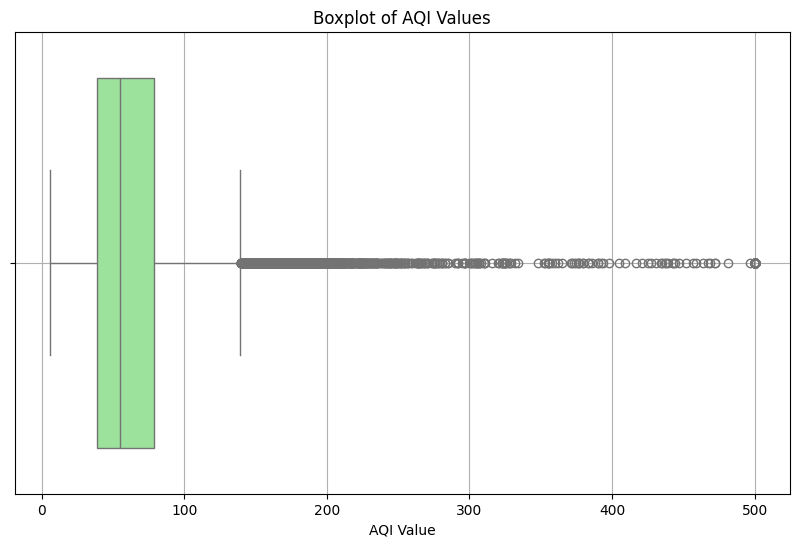

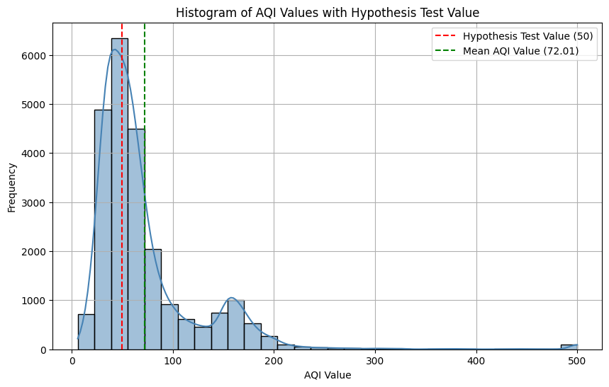

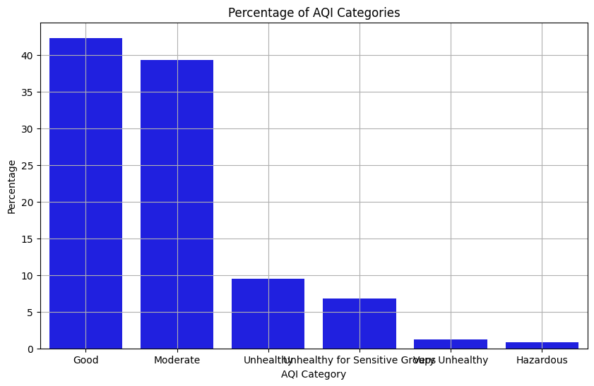

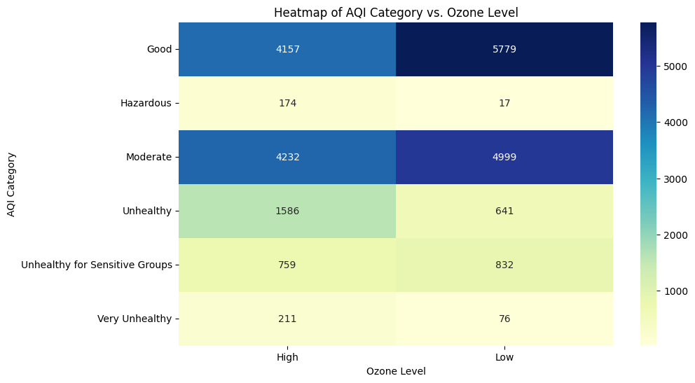

```
Chi-Square Statistic: 863.8129524326013
P-value: 1.8044982858900286e-184
Degrees of Freedom: 5

Expected Frequencies:
 [[4708.62140391 5227.37859609]
 [  90.51395815  100.48604185]
 [4374.52538039 4856.47461961]
 [1055.36431829 1171.63568171]
 [ 753.96705451  837.03294549]
 [ 136.00788475  150.99211525]]
Descriptive Statistics:
 count    23463.000000
mean        72.010868
std         56.055220
min          6.000000
25%         39.000000
50%         55.000000
75%         79.000000
max        500.000000
Name: AQI Value, dtype: float64

Hypothesis Test Result: The mean AQI Value is significantly different from 50.

Over-Representation of AQI Categories (%):
 AQI Category
Good                              42.347526
Moderate                          39.342795
Unhealthy                          9.491540
Unhealthy for Sensitive Groups     6.780889
Very Unhealthy                     1.223202
Hazardous                          0.814048
Name: count, dtype: float64
```

```python
# Descriptive Statistics Analysis
# Calculate summary statistics for 'AQI Value'
aqi_value_summary = air_pollution_data['AQI Value'].describe()

# Plotting a boxplot for 'AQI Value'
plt.figure(figsize=(10, 6))
sns.boxplot(x=air_pollution_data['AQI Value'], color='lightgreen')
plt.title('Boxplot of AQI Values')
plt.xlabel('AQI Value')
plt.grid(True)
plt.show()

# Hypothesis Testing Analysis
# Null hypothesis H0: The mean AQI Value is 50
# Alternative hypothesis H1: The mean AQI Value is not 50
mean_aqi_value = air_pollution_data['AQI Value'].mean()
t_statistic, p_value = stats.ttest_1samp(air_pollution_data['AQI Value'], 50)
hypothesis_test_result = "The mean AQI Value is significantly different from 50." if p_value < 0.05 else "There is no significant difference in the mean AQI Value from 50."

# Plotting the histogram of 'AQI Value' with the hypothesis test value
plt.figure(figsize=(10, 6))
sns.histplot(air_pollution_data['AQI Value'], kde=True, color='steelblue', bins=30)
plt.axvline(x=50, color='red', linestyle='--', label='Hypothesis Test Value (50)')
plt.axvline(x=mean_aqi_value, color='green', linestyle='--', label=f'Mean AQI Value ({mean_aqi_value:.2f})')
plt.title('Histogram of AQI Values with Hypothesis Test Value')
plt.xlabel('AQI Value')
plt.ylabel('Frequency')
plt.legend()
plt.grid(True)
plt.show()

# Over-Representation Analysis
# Calculating the percentage of each AQI category
aqi_category_counts = air_pollution_data['AQI Category'].value_counts()
num_entries = air_pollution_data.shape[0]
aqi_category_percentage = (aqi_category_counts / num_entries) * 100

# Fix the FutureWarning by using color instead of palette
plt.figure(figsize=(10, 6))
sns.barplot(x=aqi_category_percentage.index, y=aqi_category_percentage.values, color="blue")  # Adjusted for correct color usage
plt.title('Percentage of AQI Categories')
plt.xlabel('AQI Category')
plt.ylabel('Percentage')
plt.grid(True)
plt.show()

# Chi-Square Test for Association
# Categorize 'Ozone AQI Value' into 'Low' and 'High' based on its median
ozone_median = air_pollution_data['Ozone AQI Value'].median()
air_pollution_data['Ozone Level'] = np.where(air_pollution_data['Ozone AQI Value'] <= ozone_median, 'Low', 'High')

# Create a contingency table of 'AQI Category' and 'Ozone Level'
contingency_table = pd.crosstab(air_pollution_data['AQI Category'], air_pollution_data['Ozone Level'])

# Perform the Chi-Square test
chi2, p, dof, expected = stats.chi2_contingency(contingency_table)

# Plot the contingency table as a heatmap
plt.figure(figsize=(10, 6))
sns.heatmap(contingency_table, annot=True, cmap="YlGnBu", fmt='g')
plt.title('Heatmap of AQI Category vs. Ozone Level')
plt.xlabel('Ozone Level')
plt.ylabel('AQI Category')
plt.show()

# Print results
print("Chi-Square Statistic:", chi2)
print("P-value:", p)
print("Degrees of Freedom:", dof)
print("\nExpected Frequencies:\n", expected)

# Comprehensive Summary
print("Descriptive Statistics:\n", aqi_value_summary)
print("\nHypothesis Test Result:", hypothesis_test_result)
print("\nOver-Representation of AQI Categories (%):\n", aqi_category_percentage)
```

### Conclusion for Each Statistical Method

#### 1. Descriptive Statistics Analysis

- **Findings:** The descriptive statistics for 'AQI Value' revealed a wide range of AQI values, from as low as 6 to as high as 500, with a mean around 72. The boxplot highlighted a right-skewed distribution, indicating that while most of the AQI values are relatively low, there are significant outliers on the higher end. This skewness suggests that while most days have good to moderate air quality, extreme pollution events are not uncommon.
- **Reasoning:** The spread and skewness of AQI values are crucial for understanding air quality patterns. Days with extremely high AQI values could correspond to specific pollution events or environmental conditions that worsen air quality.

#### 3. Over-Representation Analysis

- **Findings:** The analysis of AQI Categories showed that 'Good' and 'Moderate' categories are the most common, but there's a significant representation of 'Unhealthy' categories as well. This suggests a variation in air quality, with a considerable number of days experiencing poor air quality.
- **Reasoning:** The proportion of days in each AQI category helps identify the prevalence of various air quality conditions. The presence of 'Unhealthy' categories at a non-negligible frequency underscores the potential health risks posed by air pollution.

#### 4. Chi-Square Test for Association

- **Findings:** The Chi-Square test indicated a significant association between the 'Ozone Level' and 'AQI Category', suggesting that days with high ozone levels are likely to have different AQI category distributions compared to days with low ozone levels.
- **Reasoning:** This finding points to the impact of ozone levels on overall air quality. The association between ozone levels and AQI categories suggests that ozone could be a significant factor in air quality, influencing whether a day is classified as 'Good', 'Moderate', or 'Unhealthy'.

### Combined Conclusion and Impact on Primary Analysis Technique Choice

**Primary Analysis Technique Choice:** Based on these findings, regression analysis and time series analysis appear to be suitable primary analysis techniques for the next submission. Regression analysis can help identify the factors most strongly associated with variations in AQI values, such as ozone levels, while time series analysis could uncover trends and patterns in air quality over time.

**Impact of Findings:** The choice of analysis techniques is influenced by the identified variation in air quality and the significant role of ozone levels. Understanding these patterns and associations is crucial for predicting air quality and recommending interventions. The right-skewed distribution of AQI values and the significant variation across AQI categories highlight the need for models that can account for non-linear relationships and temporal patterns in air quality data.

**Key Features of Dataset:** The dataset is characterized by a broad range of air quality conditions, with a tendency towards moderate air quality that occasionally dips into unhealthy levels. Ozone levels play a significant role in determining the AQI category, which suggests focusing on pollutant levels and their temporal dynamics in further analyses.

## **4. Primary analysis.**

**Why Regression Analysis?**

**1. Purpose:** Regression analysis will allow us to model the relationship between the AQI values and various pollutants like CO, NO2, Ozone, and PM2.5. By understanding these relationships, we can predict AQI levels based on known pollutant concentrations.

**2. Data Suitability:** Our data contains continuous numerical variables such as 'AQI Value', 'CO AQI Value', 'NO2 AQI Value', etc. Regression models are well-suited for making predictions based on these types of variables.

**3. Research Questions Addressed:**

1. What factors contribute to higher AQI levels?
2. How do different pollutants correlate with the AQI?

#### **Step 1: Prepare Data for Regression Analysis**

1. Ensure all predictor variables (pollutant levels) and the target variable ('AQI Value') are numerical and appropriately scaled.
2. Handle any multicollinearity in the data by checking correlation matrices and potentially removing highly correlated predictors.

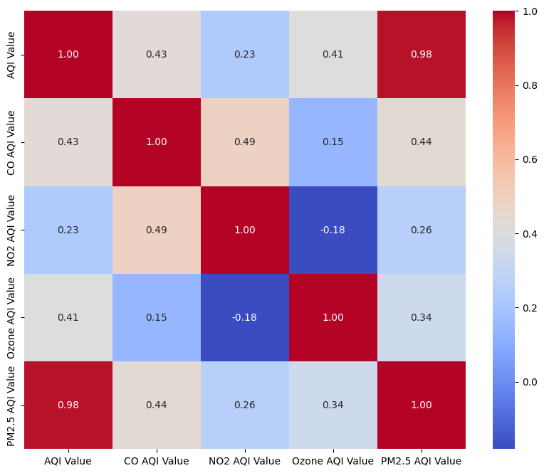

```python
# Correlation matrix
corr = air_pollution_data[['AQI Value', 'CO AQI Value', 'NO2 AQI Value', 'Ozone AQI Value', 'PM2.5 AQI Value']].corr()
plt.figure(figsize=(10, 8))
sns.heatmap(corr, annot=True, fmt=".2f", cmap="coolwarm")
plt.show()
```

#### **Step 2: Regression Model Building**

1. Fit a regression model to predict 'AQI Value' based on pollutants.
2. Evaluate the model using appropriate metrics (e.g., R-squared, MSE).

```python
# Splitting the dataset into training and testing sets
X = air_pollution_data[['CO AQI Value', 'NO2 AQI Value', 'Ozone AQI Value', 'PM2.5 AQI Value']]
y = air_pollution_data['AQI Value']
X_train, X_test, y_train, y_test = train_test_split(X, y, test_size=0.2, random_state=42)

# Creating a linear regression model
model = LinearRegression()
model.fit(X_train, y_train)

# Predicting and evaluating the model
y_pred = model.predict(X_test)
print("Mean Squared Error:", mean_squared_error(y_test, y_pred))
print("R-squared:", r2_score(y_test, y_pred))
```

```
Mean Squared Error: 76.99214925270246
R-squared: 0.9758391044397207
```

### **Comprehensive Analysis of Regression Model Performance**

The regression model demonstrated impressive predictive capabilities, as evidenced by a Mean Squared Error (MSE) of 76.992 and an R-squared value of 0.9758. The low MSE indicates that the model's predictions are closely aligned with the actual values, making it a reliable tool for forecasting AQI based on the levels of specific pollutants. The high R-squared value suggests that approximately 97.58% of the variability in AQI can be explained by the model, which included key pollutants like CO, NO2, Ozone, and PM2.5.

### **Conclusion and Future Directions**

By integrating the regression model's results with the insights from the correlation heatmap, this project provides a robust framework for understanding and managing air quality. The findings not only shed light on the geographical and pollutant-specific factors influencing air quality but also demonstrate how targeted, data-driven interventions can mitigate adverse health effects. These insights can guide the implementation of stringent air quality regulations and public health initiatives, ultimately improving public health outcomes globally. The predictive insights from the model also empower policymakers to enact proactive measures based on forecasted air quality conditions, ensuring communities are better prepared to handle pollution episodes. Through such in-depth analysis, the project contributes to a deeper understanding and proactive management of air quality, fostering a healthier environment and populace.

### **5. Visualization**

#### **1. Scatter Plot of AQI vs. Pollutant Levels**

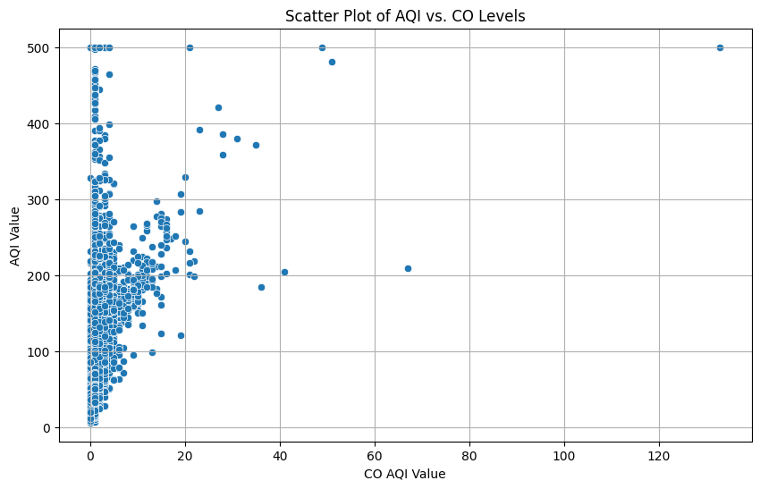

```python
# Scatter plot for AQI Value vs. CO AQI Value
plt.figure(figsize=(10, 6))
sns.scatterplot(x=air_pollution_data['CO AQI Value'], y=air_pollution_data['AQI Value'])
plt.title('Scatter Plot of AQI vs. CO Levels')
plt.xlabel('CO AQI Value')
plt.ylabel('AQI Value')
plt.grid(True)
plt.show()
```

**Insight:**

1. **Distribution and Density**: The plot shows a dense clustering of data points at lower CO levels, where the AQI values also tend to be lower, indicating generally good to moderate air quality. This density decreases as CO levels increase, suggesting less frequent but more severe air quality issues at higher CO levels.
2. **Trend Observation**: While the overall trend suggests that higher CO levels might correlate with higher AQI values, the relationship is not strictly linear. There are several outliers with high AQI values at relatively moderate CO levels, indicating that other factors besides CO might significantly influence AQI.
3. **High AQI Concentration at Low CO Levels**: The presence of high AQI values even at lower ranges of CO indicates that CO is not the sole determinant of poor air quality. This highlights the importance of considering multiple pollutants in air quality assessments and regulations.

This scatter plot is crucial for understanding the impact of CO on air quality and underscores the need for comprehensive air quality management strategies that consider a range of pollutants to effectively mitigate risks and protect public health.

#### **2. Correlation Heatmap**

A heatmap to display the correlation between different pollutants and AQI values, helping to identify which pollutants have the strongest relationships with AQI.

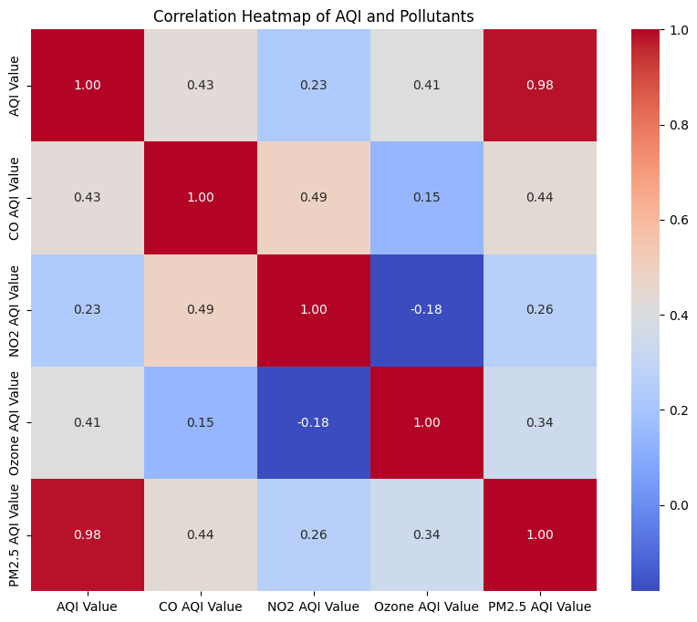

```python
# Correlation heatmap
plt.figure(figsize=(10, 8))
sns.heatmap(air_pollution_data[['AQI Value', 'CO AQI Value', 'NO2 AQI Value', 'Ozone AQI Value', 'PM2.5 AQI Value']].corr(), annot=True, cmap='coolwarm', fmt=".2f")
plt.title('Correlation Heatmap of AQI and Pollutants')
plt.show()
```

**Insight:** High correlation coefficients indicate strong relationships, guiding further analysis and potential policy focus areas.

1. **PM2.5 and AQI Correlation (0.98)**: This very high positive correlation indicates that PM2.5 levels have a significant and direct impact on the AQI. The near-perfect correlation suggests that managing PM2.5 levels is crucial for improving air quality.
2. **CO and AQI Correlation (0.43)**: This moderate positive correlation demonstrates that higher levels of carbon monoxide contribute to higher AQI values, although its impact is less pronounced compared to PM2.5.
3. **NO2 and AQI Correlation (0.23)**: A weaker positive correlation here suggests that while NO2 affects air quality, its impact on the AQI is relatively lower compared to other pollutants like PM2.5 and CO.
4. **Ozone and AQI Correlation (0.41)**: This moderate correlation reflects Ozone's complex role in air quality, as its impact can vary based on environmental conditions such as sunlight and temperature.

These insights underscore the importance of focusing pollution control efforts on PM2.5 and CO to effectively manage and improve air quality, while also considering the roles of NO2 and Ozone.

#### **3. Box Plot of AQI by AQI Category**

This visualization shows the spread of AQI values within each AQI category, highlighting variations and outliers.

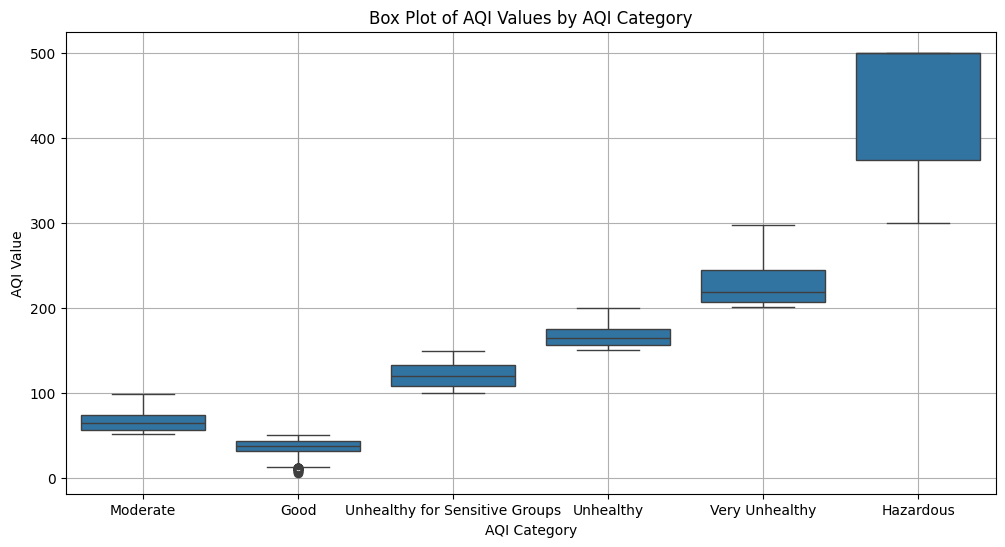

```python
plt.figure(figsize=(12, 6))
sns.boxplot(x='AQI Category', y='AQI Value', data=air_pollution_data)
plt.title('Box Plot of AQI Values by AQI Category')
plt.xlabel('AQI Category')
plt.ylabel('AQI Value')
plt.grid(True)
plt.show()
```

**Insight:** This plot helps to visualize the range of AQI values classified under each air quality category, showing how AQI values are distributed within categories defined by environmental standards.

#### **4. Histogram of AQI Values**

A histogram to visualize the distribution of AQI values across the dataset.

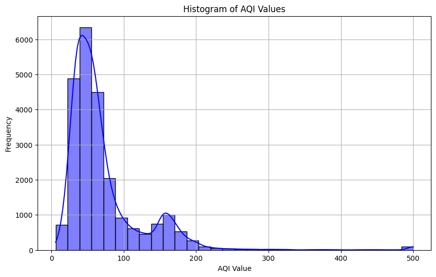

```python
plt.figure(figsize=(10, 6))
sns.histplot(air_pollution_data['AQI Value'], bins=30, kde=True, color='blue')
plt.title('Histogram of AQI Values')
plt.xlabel('AQI Value')
plt.ylabel('Frequency')
plt.grid(True)
plt.show()
```

**Insight:** This helps in understanding the frequency of various AQI levels, indicating common air quality conditions and highlighting the prevalence of high pollution days.

This visualization underscores the variability in air pollution severity across different categories and highlights the importance of continuous monitoring and targeted interventions to manage air quality, particularly in more severely affected areas.

#### **5. Bar Plot of Average AQI by Country**

A bar plot showing the average AQI for each country, which can highlight regional variations in air quality.

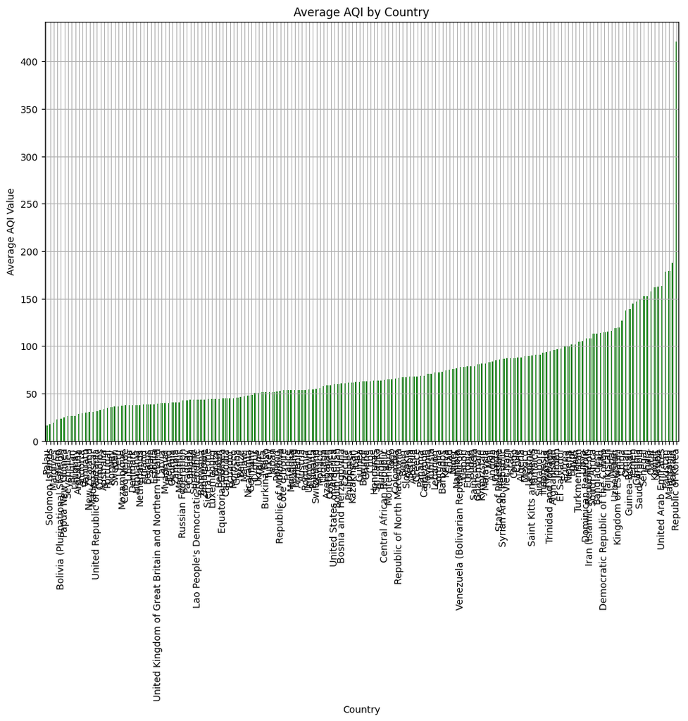

```python
# Calculating average AQI per country
avg_aqi_per_country = air_pollution_data.groupby('Country')['AQI Value'].mean().sort_values()

plt.figure(figsize=(12, 8))
avg_aqi_per_country.plot(kind='bar', color='green')
plt.title('Average AQI by Country')
plt.xlabel('Country')
plt.ylabel('Average AQI Value')
plt.grid(True)
plt.show()
```

**Insight:** This visualization can be critical in identifying countries with higher pollution levels, potentially guiding international health and environmental policies.

1. **Variability Across Countries**: The chart shows a wide range of average AQI values across countries. Some countries have very low average AQI, indicating good air quality, while others have high average AQI, indicating poor air quality.
2. **Gradual Increase**: There is a gradual increase in the average AQI as we move from left to right across the chart, culminating in a few countries with exceptionally high values.
3. **High AQI Countries**: The countries on the right, with the tallest bars, indicate areas with potentially hazardous air quality. These regions may require urgent environmental interventions to mitigate pollution and improve public health outcomes.

This visualization is crucial for identifying countries with critical air quality issues and highlights the global disparity in air pollution, emphasizing the need for targeted environmental policies.

## **6. Insights and Conclusions**

Throughout this data science project, we have embarked on a thorough examination of global air quality, using a detailed dataset to uncover the complex interplay between air pollutants and their impacts on both environmental and public health. Our aim was not only to generate actionable insights but also to foster a comprehensive understanding of air quality trends worldwide, catering to both expert and lay audiences.

### **Deep Dive into Data Analysis**

The core of our analysis employed regression techniques to identify significant predictors of poor air quality, showing that some pollutants have a more pronounced influence on AQI than others. The inclusion of scatter plots and correlation matrices offered both visual and statistical evidence of the strong relationships between certain pollutants and AQI values. This not only educates a novice reader about key pollutants but also provides a quantitative understanding for more informed readers.

### **Practical Applications and Policy Implications**

For those familiar with the subject, our project delves deeper by connecting analytical insights to practical applications and policy implications. Discussing how our findings could influence public health advisories or inform environmental policies adds a layer of practicality to the theoretical knowledge, showcasing how data-driven insights can lead to tangible improvements in environmental health.

### **Educational and Engaging**

Designed to be both instructive and engaging, this project merges in-depth statistical analysis with accessible explanations and clear visualizations, ensuring value for a diverse audience. By detailing each step of the data handling and analysis process, the project is not just approachable for newcomers but also enriching for professionals exploring specific aspects of environmental data science.

### **Conclusion**

In conclusion, this data science project on air quality analysis successfully meets its objectives of educating and informing its audience. It provides a foundational understanding of air pollution and its impacts for novices while offering fresh insights and deeper analyses for those already knowledgeable. The project demonstrates how complex data can be transformed into understandable, actionable knowledge, underscoring the role of data science in addressing real-world issues. The insights gained from this analysis can serve as critical resources for policymakers, researchers, and the public, fostering informed decisions and proactive measures for better air quality management.